# INSTRUCTIONS

- This is an individual assignment.
- Submit your answer digitally as two files through Moodle:
  - An R markdown file (extension **Rmd**). Use the template provided to you and provide your answers (both code and text) below each question.
  - An **HTML** file “knitted” by RStudio including all the results and plots. More details on how to create these files will be provided in class on week 3.
- Follow the Style Guide (available on Moodle). You can be penalized on up to 20% in each question for which you do not follow the Style Guide.
- Questions regarding the assignment should be posted exclusively on the respective discussion forum on Moodle.

**Warning:** The detection of any form of plagiarism in your work means the assignment will be graded with ZERO points.

# Movie Networks

We are interested in assessing what are the most important movies in the decade 2010-2019. We will use different strategies to do so. First, we will load and prepare the data.

## Load and prepare the data

The first step is to load and prepare the movie data. The following instructions perform some routine data preparation operations. Each set of instructions is preceded by a comment explaining the procedure. Run the code below and try to understand each line of code as you might need to perform some changes.

```r
library(data.table)     # Run once per session
library(ggplot2)        # Run once per session

# Load data from file 20200120-imdb_movie_actor.csv (do not forget to
# change your working directory to the folder containing the
# 20200120-imdb_movie_actor.csv file)
dt.movie.actor <- fread("20200120-imdb_movie_actor.csv")

# Count in how many movies each actor has participated and how many
# principal actor each movie has
dt.movie.actor[, n_movies := .N, by=actor]
dt.movie.actor[, n_actors := .N, by=list(movie, year)]

# Remove entries in which actors have no name
dt.movie.actor <- dt.movie.actor[!(actor == "")]

# Save dt.movie.actor. Next time you can simply call the load function (below)
save(dt.movie.actor, file="imdb_movie_actor.RData")
```

Load the data that you prepared using the instructions below. As mentioned in the comments, you can start from this line if you have previously saved these data.

```r
library(data.table)     # Run once per session
library(ggplot2)        # Run once per session
# Load previously saved dt.movie.actor. You can
# start in this line if you have previously saved these data.
load("imdb_movie_actor.RData")
```

## Questions (`data.table`) `[7 points]`

This set of questions require that you know how to manipulate a `data.table`. Answer each of the following questions below. Include all the code you created/used in your answer.

1. What is the total amount of movies in the `dt.movie.actor` dataset? `[1 point]`

```r
# <answer here>
# Get the unique values of the total number of movies---------------------------

unique.total.movies <- NROW(unique(dt.movie.actor$movie))

# Print the unique value of total movies----------------------------------------

cat("The total amount of movies is", unique.total.movies, "\n")
```

```
## The total amount of movies is 368522
```

The total amount of movies is 368522

2. List the actors from the movie `"Fight Club (1999)"`. List the actors from the movie `"Se7en (1995)"`. `[1 point]`

```r
# <answer here>
# List and print the actors from "Fight Club (1999)"----------------------------

l.fight.club.actors <- as.list(dt.movie.actor$actor[dt.movie.actor$movie ==
                                                      "Fight Club (1999)"])

cat("Actors from 'Fight Club (1999)':\n", paste(l.fight.club.actors,
                                                collapse = ", "), "\n")
```

```
## Actors from 'Fight Club (1999)':
##  Brad Pitt (b.1963), Meat Loaf (b.1947), Edward Norton (b.1969), Zach Grenier (b.1954)
```

```r
# List and print the actors from "Se7en (1995)"---------------------------------

l.se7en.actors <- as.list(dt.movie.actor[movie == "Se7en (1995)"][, actor])


cat("Actors from 'Se7en (1995)':\n", paste(l.se7en.actors, collapse = ", "),
    "\n")
```

```
## Actors from 'Se7en (1995)':
##  Brad Pitt (b.1963), Morgan Freeman (b.1937), Kevin Spacey (b.1959), Andrew Kevin Walker (b.1964)
```

3. Which actors participated on both movies? Hint: The function `intersect` calculates the intersection of two sets. `[1 point]`

```r
# <answer here>
# Find and print the actors who participated in fight.club and se7en------------

l.common.actors <- intersect(l.fight.club.actors, l.se7en.actors)

cat("Actors who participated in both 'Fight Club (1999)' and 'Se7en (1995)':\n",
    paste(l.common.actors, collapse = ", "), "\n")
```

```
## Actors who participated in both 'Fight Club (1999)' and 'Se7en (1995)':
##  Brad Pitt (b.1963)
```

4. In which movies did Brad Pitt (b.1963) and George Clooney (b.1961) star together? `[1 point]`

```r
# <answer here>
# Find and print the movies with Brad Pitt (b.1963) and #George Clooney (b.1961)
# ------------------------------------------------------------------------------
movies.brad.pitt <- dt.movie.actor$movie[dt.movie.actor$actor ==
                                           "Brad Pitt (b.1963)"]

movies.george.clooney <- dt.movie.actor$movie[dt.movie.actor$actor ==
                                                "George Clooney (b.1961)"]

movies.both.actors <- intersect(movies.brad.pitt, movies.george.clooney)

cat("Movies in which Brad Pitt and George Clooney starred together:\n",
    paste(movies.both.actors, collapse = ", "), "\n")
```

```
## Movies in which Brad Pitt and George Clooney starred together:
##  Ocean's Eleven (2001), Ocean's Twelve (2004), Ocean's Thirteen (2007), Burn After Reading (2008)
```

5. Create a table that shows the number of movies released per year. This table should include three columns: `year`, `n_movies`, and `csum_n_movies`. The first column should contain the year, the second the number of movies in that year, and the third, the number of movies released since the first year in the data and up to the year in that line. Tip: Use the function `cumsum` and check if the amount in the last year is the same as the total number of movies in question 1. `[1 point]`

```r
# <answer here>
# create a new data table with the number of movies per year and csum_n_movies--
# ------------------------------------------------------------------------------
dt.unique.movies <- unique(dt.movie.actor, by = c("year", "movie"))

dt.movies.per.year <- dt.unique.movies[, .(n_movies = .N),
                                       by = year][order(year)]
dt.movies.per.year[, csum_n_movies := cumsum(n_movies)]

print(dt.movies.per.year)
```

```
##      year n_movies csum_n_movies
##   1: 1894        1             1
##   2: 1899        1             2
##   3: 1900        1             3
##   4: 1905        2             5
##   5: 1906        4             9
##  ---
## 114: 2015    10731        322844
## 115: 2016    11409        334253
## 116: 2017    11667        345920
## 117: 2018    11775        357695
## 118: 2019    10827        368522
```

```r
# Check if the total number of movies in question 1 is equal to the last line of
# the new data table------------------------------------------------------------

cat("\n The sum of number of movies (last row) is ",
    paste(tail(cumsum(dt.movies.per.year$n_movies), n = 1)), " this shows the
    same result as the total number of movies from question 1\n")
```

```
##
##  The sum of number of movies (last row) is  368522  this shows the
##     same result as the total number of movies from question 1
```

6. Which actor/actress has starred in the most movies across all data? After (and including) 2000, which year has the most movie participations by a single actor/actress? Who is that actor/actress? What do these two actors/actresses have in common? `[1 point]`

```r
# <answer here>
# Actor/actress in the most movies in all data----------------------------------

dt.actor.counts <- dt.movie.actor[, .(n_movies = .N), by = actor]
dt.sorted.movies <- dt.actor.counts[order(-n_movies)][1]

cat("\n Actor/actress in the most movies in all data\n")
```

```
##
##  Actor/actress in the most movies in all data
```

```r
print(dt.sorted.movies)
```

```
##                    actor n_movies
## 1: Brahmanandam (b.1956)      804
```

```r
# Actor with most movies from year 2000 (incl.)---------------------------------

dt.movies.2000 <- dt.movie.actor[year >= 2000][order(year)]
dt.actor.counts.2000 <- dt.movies.2000[, .(n_movies = .N), by = .(actor, year)]
dt.sorted.movies.2000 <- dt.actor.counts.2000[order(-n_movies)][1]

cat("\n Actor with most movies from year 2000 (incl.)\n")
```

```
##
##  Actor with most movies from year 2000 (incl.)
```

```r
print(dt.sorted.movies.2000)
```

```
##           actor year n_movies
## 1: Anil Nagrath 2001       35
```

```r
# Common features of both actors------------------------------------------------

cat("\nThe actor/actress", dt.sorted.movies$actor,
    "has an birthdate behind the name and the actor/actress",
    dt.sorted.movies.2000$actor, "has no birthday behind the name")
```

```
##
## The actor/actress Brahmanandam (b.1956) has an birthdate behind the name and the actor/actress Anil Nagrath has no birthday behind the name
```

```r
# Check if both played in one movie

movies.brahmanandam <- dt.movie.actor$movie[dt.movie.actor$actor ==
                                              "Brahmanandam (b.1956)"]
movies.anil <- dt.movie.actor$movie[dt.movie.actor$actor ==
                                      "Anil Nagrath"]
movies.both.actors.c <- intersect(movies.brahmanandam, movies.anil)
print(movies.both.actors.c)
```

```
## character(0)
```

```r
# Calculating the common features of both actors and check each column----------
# First create a data table for each actor--------------------------------------

dt.movies.brahmanandam <- dt.movie.actor[actor == "Brahmanandam (b.1956)"]
dt.movies.anil <- dt.movie.actor[actor == "Anil Nagrath"]

# Check common features for year------------------------------------------------

common.year <- intersect(dt.movies.brahmanandam$year[
  !is.na(dt.movies.brahmanandam$year)],
  dt.movies.anil$year[!is.na(dt.movies.brahmanandam$year)])

# Check common features for duration--------------------------------------------

common.duration <- intersect(dt.movies.brahmanandam$duration[
  !is.na(dt.movies.brahmanandam$duration)],
  dt.movies.anil$duration[!is.na(dt.movies.anil$duration)])

# Check common features for adult_movies----------------------------------------

common.adult.movies <- intersect(dt.movies.brahmanandam$adult_movies[
  !is.na(dt.movies.brahmanandam$adult_movies)],
  dt.movies.anil$adult_movies[!is.na(dt.movies.anil$adult_movies)])

# Check common features for rating----------------------------------------------

common.rating <- intersect(dt.movies.brahmanandam$rating[
  !is.na(dt.movies.brahmanandam$rating)],
  dt.movies.anil$rating[!is.na(dt.movies.anil$rating)])

# Check common features for votes-----------------------------------------------

common.votes <- intersect(dt.movies.brahmanandam$votes[
  !is.na(dt.movies.brahmanandam$votes)],
  dt.movies.anil$votes[!is.na(dt.movies.anil$votes)])

cat("\nBoth actors participated in movies in the following years ",
    common.year)
```

```
##
## Both actors participated in movies in the following years  1997 1995 1998 2001 2000 2003 2002 2004 2005 1999 2006 2012
```

```r
cat("\nBoth actors participated in a number of ",
    length(common.duration), " movies with the same duration")
```

```
##
## Both actors participated in a number of  18  movies with the same duration
```

```r
cat("\nBoth actors participated in a number of ",
    length(common.adult.movies), " adult_movies")
```

```
##
## Both actors participated in a number of  0  adult_movies
```

```r
cat("\nBoth actors participated in a number of ",
    length(common.rating), " movies with the same rating")
```

```
##
## Both actors participated in a number of  17  movies with the same rating
```

```r
cat("\nBoth actors participated in ", length(common.votes),
    " movies with the same votes")
```

```
##
## Both actors participated in  15  movies with the same votes
```

7. Consider only the 10% most popular movies (by votes) in the decade 2010-2019. List the top 10 actors that starred in the most movies in the decade. Which year(s) has/have the most movie participations by a single actor? Hint: you can use the function `quantile` to find how many votes does the movie in percentile 90 have. `[1 point]`

```r
# <answer here>

# List the top 10 actors that starred in the most movies in the decade 2010-1019
# ------------------------------------------------------------------------------
dt.movies.decade <- dt.movie.actor[year >= 2010 & year < 2020]
dt.movies.decade.unique <- unique(dt.movies.decade, by = "movie")
dt.sorted.votes <- dt.movies.decade[order(votes, decreasing = TRUE)]

# Calculation of 90 percentile of number of votes and dropping of NA's----------

dt.votes.no.na <- dt.sorted.votes[complete.cases(dt.sorted.votes$votes)]
dt.votes.threshold <- quantile(dt.votes.no.na$votes, 0.9)

cat("90 percentile of the number of votes is:", dt.votes.threshold, "votes")
```

```
## 90 percentile of the number of votes is: 1987 votes
```

```r
# Filter the data to include only the 10% most popular movies by votes----------

dt.popular.movies <- dt.movies.decade[dt.movies.decade$votes >=
                                        dt.votes.threshold][order(votes,
                                                                  decreasing =
                                                                    TRUE)]

# Count the top 10 actors by number of movies in the decade---------------------

l.top.10.actors <- as.list(dt.popular.movies[, . (n_movies = .N), by =
                                               actor][order(-n_movies)][1:10])

dt.top.10.actors <- dt.popular.movies[, . (n_movies = .N), by =
                                        actor][order(-n_movies)][1:10]


cat("\n\nThe top 10 actors in the decade 2010-2019 by number of movies are ",
    paste(l.top.10.actors, collapse = ", "), "\n\n")
```

[output not shown]

```r
head(dt.top.10.actors, 10)
```

```
##                           actor n_movies
##  1:       Akshay Kumar (b.1967)       36
##  2:       Nicolas Cage (b.1964)       33
##  3:       James Franco (b.1978)       26
##  4:     Robert De Niro (b.1943)       24
##  5:       Bruce Willis (b.1955)       24
##  6:      Anna Kendrick (b.1985)       24
##  7:  Samuel L. Jackson (b.1948)       23
##  8:        John Cusack (b.1966)       23
##  9: Michael Fassbender (b.1977)       22
## 10: Chloë Grace Moretz (b.1997)       22
```

```r
# Calculate the number of movies each actor starred in per year-----------------

dt.actor.participations.year <- dt.popular.movies[, . (n_movies = .N), by =
                                                    .(actor,
                                                      year)][order(-n_movies)]

# Get the year(s) with the most movie participations by a single actor----------

dt.top.years.by.actor <- dt.actor.participations.year[1:2]

print(dt.top.years.by.actor)
```

```
##                       actor year n_movies
## 1:     Liam Neeson (b.1952) 2014        7
## 2: Woody Harrelson (b.1961) 2017        6
```

```r
cat("\n\nThe year(s) with most movie participations by a single actor in the
    decade 2010-2019 by the number of movies are ",
    paste(dt.top.years.by.actor$year, collapse = ", "), "\n")
```

[output not shown]

## Questions (`ggplot2`) `[3 points]`

1. Plot a histogram with the number of movies per year. Which patterns do you observe? Is there anything strange? `[1 point]

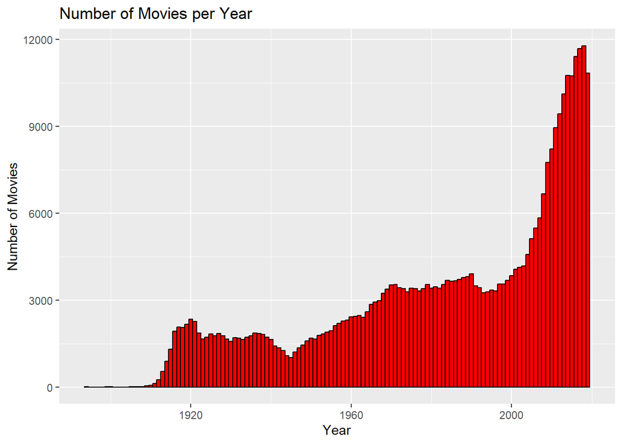

```r
# <answer here>
library(ggplot2)

# Unique movies per year to prevent double count of movies----------------------

dt.movies.unique.per.year <- unique(dt.movie.actor, by = "movie")

# Count the number of movies per year-------------------------------------------

dt.movies.sum.per.year <- dt.movies.unique.per.year[, .(n_movies = .N),
                                                    by = year]

# Plot the histogram of the numbers of movies per year--------------------------

ggplot(dt.movie.actor[!duplicated(dt.movie.actor$movie)], aes(x = year)) +
  geom_histogram(binwidth = 1, color = "black", fill = "red") +
  xlab("Year") +
  ylab("Number of Movies") +
  ggtitle("Number of Movies per Year")
```

2. Plot a histogram that represents the distribution of number of IMDb votes per movie. The x-axis should represent the number of votes and the y-axis should represent how many movies have x number of votes. Which patterns do you observe? `[1 point]`

Observation:

There is a clear pattern that the number of movies decreases as the number of votes increases. Most movies have votes up to 100 and the middle part goes up to 10,000 votes. After that, the number continues to decrease sharply to 0.Thus, a few movies have votes of up to 2 million.

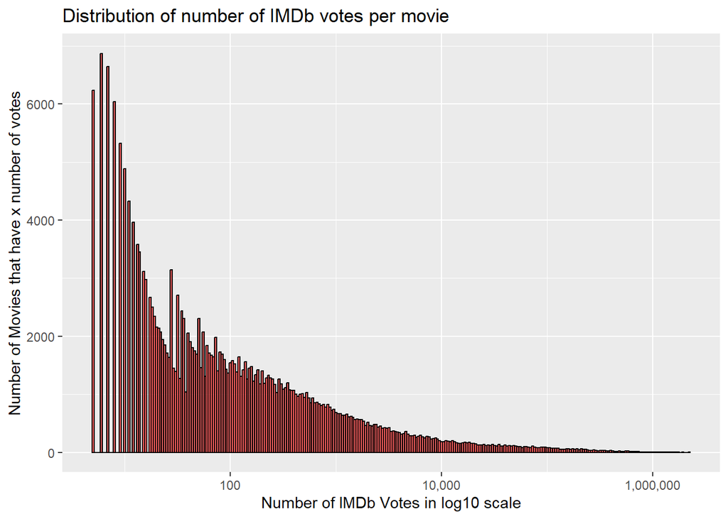

```r
# <answer here>
# Create histogram of the distribution of number of IMDb votes per movies-------

ggplot(dt.movie.actor[!duplicated(dt.movie.actor$movie)], aes(x = votes)) +
  geom_histogram(binwidth = 0.02, color = "black", fill = "red", alpha = 0.6,
                 na.rm = TRUE) +
  scale_x_log10(labels=scales::comma) +
  xlab("Number of IMDb Votes in log10 scale") +
  ylab("Number of Movies that have x number of votes") +
  ggtitle("Distribution of number of IMDb votes per movie")
```

3. Plot a histogram that represents the distribution of the number of actors per movie. The x-axis should represent the number of actors and the y-axis should represent how many movies have x number of actors. Describe your findings. `[1 point]`

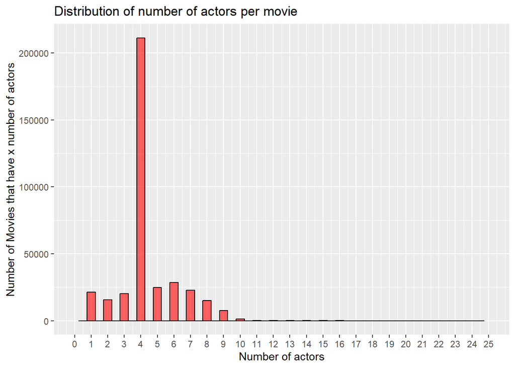

```r
# <answer here>
# Count the number of actors per movies by grouping over movies and
# count actor per group---------------------------------------------------------

dt.actors.per.movies <- dt.movie.actor[, .(n_actors = uniqueN(actor)), by =
                                         movie]

# Plot histogram of distribution of the number of actors per movie--------------

ggplot(dt.actors.per.movies, aes(x = n_actors)) +
  geom_histogram(binwidth = 0.5, color = "black", fill = "red", alpha = 0.6,
                 na.rm = TRUE) +
  scale_x_continuous(limits = c(0, 25), breaks = seq(0, 25, by = 1)) +
  xlab("Number of actors") +
  ylab("Number of Movies that have x number of actors") +
  ggtitle("Distribution of number of actors per movie")
```

## Questions (`igraph`) `[10 points]`

1. From this question onwards, and until the end of the assignment, focus only on the actors that participated on the top 50 most popular movies from the 2010-2019 decade (by number of votes). Load the `igraph` package and create a bipartite graph in which the edges correspond to actors’ participation in movies. How many movie participations exist? `[1 point]`

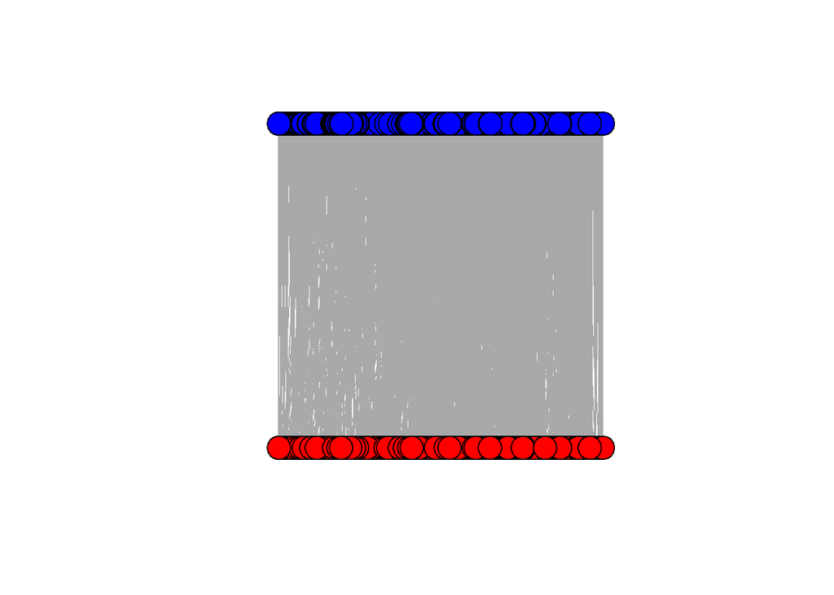

```r
# <answer here>
library(igraph)
# Actors that participated on the top 50 most popular movies from 2010-2019
# decade by number of votes-----------------------------------------------------

# Filter the unique movies from 2010-2019 and select the top 50 by number
# of votes----------------------------------------------------------------------

dt.actors.top.50.movies.unique <- unique(dt.movie.actor, by = "movie")
dt.actors.top.50.movies <- dt.actors.top.50.movies.unique[year >= 2010 &
                                                            year <= 2019][order(
                                                              -votes)][1:50,
                                                                       .(movie)]


# Join the top 50 movies with the movie-actor data to get all details back------

dt.top.50.actors.decade <- dt.movie.actor[movie %in%
                                            dt.actors.top.50.movies$movie]
dt.all.movies.selected.actors <- dt.movie.actor[actor %in%
                                                  dt.top.50.actors.decade$actor]

# Create a bipartite graph of movies and actors---------------------------------

all.actors <- dt.all.movies.selected.actors[, list(name = unique(actor),
                                                   type = TRUE)]
all.movies <- dt.all.movies.selected.actors[, list(name = unique(movie),
                                                   type = FALSE)]

all.vertices <- rbind(all.actors, all.movies)
g.movies.50 <- graph.data.frame(dt.all.movies.selected.actors[, list(movie,
                                                                     actor)],
                                directed = FALSE, vertices=all.vertices)

# Plot the bipartite graph g.movies.50------------------------------------------

V(g.movies.50)$color <- ifelse(V(g.movies.50)$type == 1, "red", "blue")

plot(g.movies.50, layout = layout.bipartite(g.movies.50), vertex.label = NA)
```

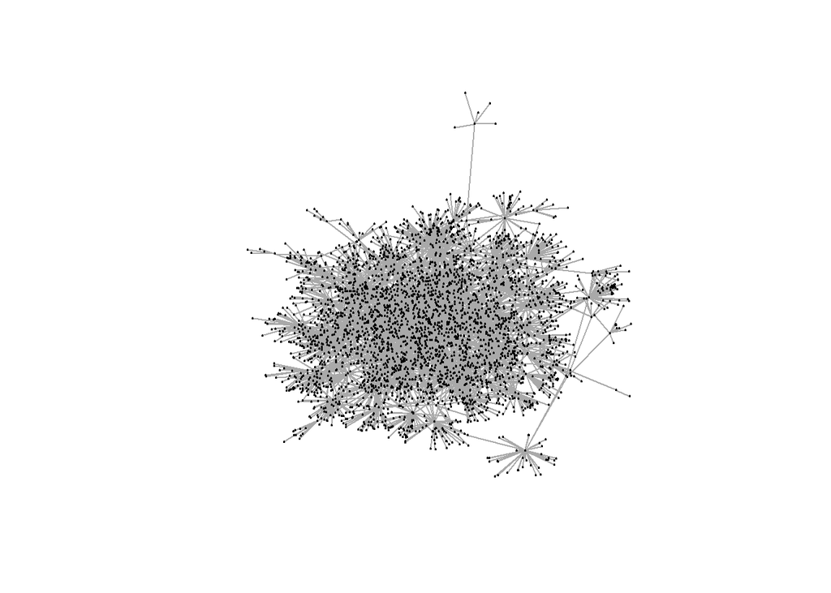

```r
plot(g.movies.50, layout = layout_with_fr, vertex.color = V(g.movies.50)$color,
     vertex.label = NA, vertex.size = 1, margin = -0.1)
```

```r
# Calculate the number of movie participations----------------------------------

num.participations <- length(E(g.movies.50))

cat("The number of movie participations is", num.participations, "\n\n")
```

```
## The number of movie participations is 3872
```

```r
summary(g.movies.50)
```

```
## IGRAPH 657031d UN-B 3351 3872 --
## + attr: name (v/c), type (v/l), color (v/c)
```

2. Create a graph in which two movies are connected to each other if they have at least one actor in common. Calculate the degree centrality for each of the movies, and remove movies with no connections to other movies. Hint: the function `induced.subgraph` allows the creation of graphs with only a subset of the vertices. Calculate the following additional centrality measures for each of these movies: `[2 points]`
   - Closeness centrality
   - Betweenness centrality
   - Eigenvector centrality

```r
# <answer here>

# Get the unipartite projection 1 of movies which show two movies are connected
# to each other of they have at least one actor in common-----------------------

g.movies.proj.1 <- bipartite.projection(g.movies.50)$proj1

# Test if th graph contains movie with a degree of 0----------------------------


degrees.proj.1 <- degree(g.movies.proj.1)
isolated.movies <- which(degrees.proj.1 == 0)

cat("\nNumber of movies with a degree of zero in the projection 1 graph\n")
```

```
##
## Number of movies with a degree of zero in the projection 1 graph
```

```r
print(isolated.movies)
```

```
## named integer(0)
```

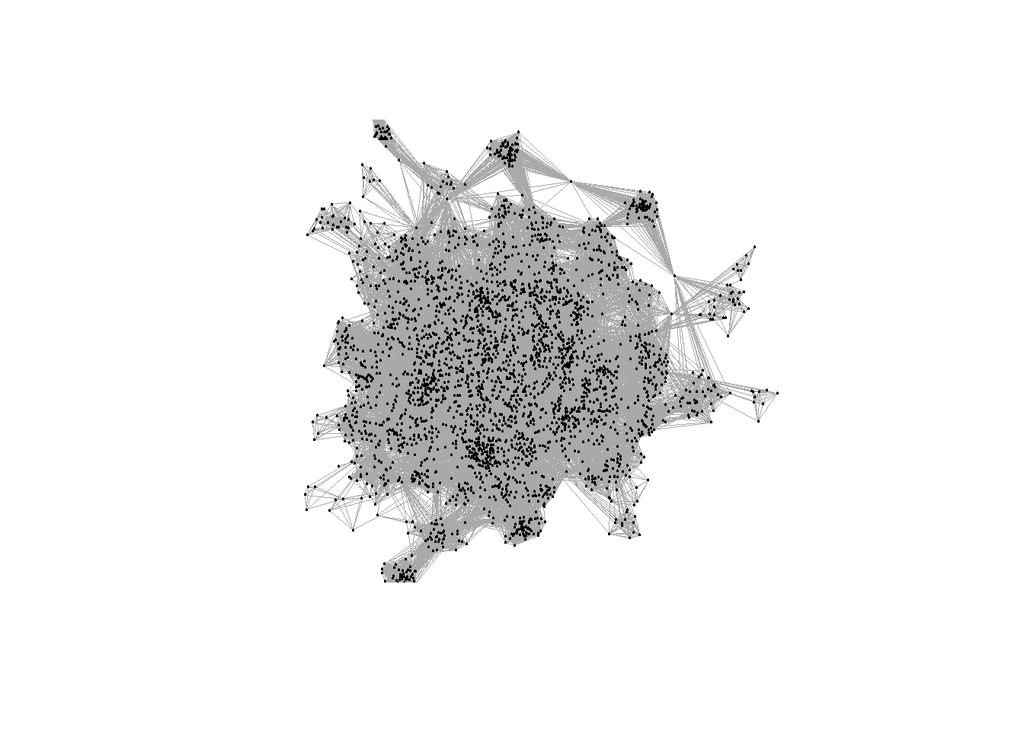

```r
# Create and plot the subgraph with only connected movies including the summary
# ------------------------------------------------------------------------------

g.movies.subgraph <- induced.subgraph(g.movies.proj.1,
                                      which(degree(g.movies.proj.1) > 0))

plot(g.movies.subgraph, layout = layout_with_fr,
     vertex.color = V(g.movies.subgraph)$color, vertex.label = NA,
     vertex.size = 1, margin = -0.1, edge.width = 0.01)
```

```r
summary(g.movies.subgraph)
```

```
## IGRAPH 66e21d7 UNW- 3207 68196 --
## + attr: name (v/c), color (v/c), weight (e/n)
```

```r
# Calculate degree centrality and remove movies from data source without
# connections-------------------------------------------------------------------

g.movies.remove <- delete.vertices(g.movies.proj.1,
                                   degree(g.movies.proj.1) == 0)

degree.centrality <- degree(g.movies.remove, mode = "all")

closeness <- closeness(g.movies.remove)
betweenness <- round(betweenness(g.movies.remove), 4)
eigenvector <- round(evcent(g.movies.remove)$vector, 4)

# Create and print a dataframe with centrality measures-------------------------

df.centrality.measures.movies <- data.frame(degree = degree.centrality,
                                            closeness = closeness,
                                            betweenness = betweenness,
                                            eigenvector = eigenvector)

print(df.centrality.measures.movies)
```

[output not shown]

[output cut: 12773 more lines]

```
## Tiger House (2015)                                                                                        0.0006
## The Transporter Refueled (2015)                                                                           0.0006
## Sword of Vengeance (2015)                                                                                 0.0006
## The Model (2016)                                                                                          0.0006
## In Darkness (2018)                                                                                        0.0006
## Born a King (2019)                                                                                        0.0006
## Scrawl (2015)                                                                                             0.0000
## Star Wars: Episode IX - The Rise of Skywalker (2019)                                                      0.0000
## The Eagle Huntress (2016)                                                                                 0.0000
## Ophelia (2018)                                                                                            0.0000
## Slice (2018)                                                                                              0.0123
## Sollers Point (2017)                                                                                      0.0123
## Wounds (2019)                                                                                             0.0123
## The Undiscovered Country (2019)                                                                           0.0123
## Dead Pigs (2018)                                                                                          0.0123
```

3. For each centrality measure, list the top 20 movies with highest centrality. How do you interpret the outcomes? `[2 points]`

Interpretation of the outcome:

General procedure: Using of round(closeness(g, normalize=TRUE), 2) gives a better idea of the relative closeness centrality values of the vertices in the graph, because the normalized values are rescaled to a range between 0 and 1 where 1 represents the highest possible closeness centrality value that can be achieved in the graph. This allows for a comparison of the closeness centrality values across different graphs, even if they have different numbers of vertices.

The network is therefore very large with 3207 nodes and 68196 edges. In the following, I refer to the absolute values of the measures. For better interpretation, the normalized value for the top 20 movies is used, as the absolute value is not interpretable and is either very small or very large for almost all movies.

The low degree, such as with Captain America: The Winter Soldier (2014) with 0.0577, shows that the movies are not really closely and well connected to all other movies but rather form a chain, as I assume. This also means that no movie is extremely important for the network and the network would not collapse or affect many other nodes if the movie were lost.

The closeness of the top 20 movies is rather in the lower middle range, with Shutter Island (2010) with 0.4051, for example. This value shows that the movies are not closely and easily reachable. So it is not impossible but also not very easy to get to other movies quickly and directly. This is also related to the low degree and thus the lack of close connectivity among the top 20 movies. The movies with the highest closeness centrality are the ones that can be reached the quickest from any other movie in the network. In our case no movie has an really high closeness.

Betweenness measures the extent to which a node lies on the shortest path between other pairs of nodes in a network. Nodes with high betweenness centrality are important because they act as bridges between different parts of the network. The betweenness approaches zero, so the top movie, The Grand Budapest Hotel (2014), has a betweenness of 0.0509. This means that a movie is not often taken as a bridge to other pairs of nodes in order to get to movies in other parts of the network. Therefore, this measure is also dependent on the low degree. The movies do not play a big role in the interaction and communication of information exchange among themselves.

The only value that naturally lies between 0 and 1 and is not already normalized is the eigenvector. Nodes with high eigenvector centrality are those that are connected to other highly central nodes. This value is close to the maximum of 1. This means that the top 20 movies are extremely well connected to each other. This is also evident when plotting the large graph, which is a large central cloud and not widely scattered except for a few movies that are apparently less popular. Therefore, individual edges cannot be recognized, and it is more like a large cloud. The high eigenvector is also due to the fact that popular movies usually also share popular actors. This is the case because a movie becomes more well-known and popular when popular actors appear in it, drawing fans and viewers to the cinema.Finally, the top 20 movies with the highest eigenvector centrality are the ones that are connected to other important movies in the network.

Overall, it is a large and centrally located network, but poorly connected to each other. This means that information exchange is not guaranteed, and the individual movies are not connected to all but rather form a chain.

```r
# <answer here>

# Normalized centrality measures for better interpretations---------------------

normalized.degree <- round(degree(g.movies.remove, normalized = TRUE), 4)
normalized.closeness <- round(closeness(g.movies.remove, normalize = TRUE), 4)
normalized.betweenness <- round(betweenness(g.movies.remove,
                                            normalize = TRUE), 4)


# Degree centrality-------------------------------------------------------------

df.top.degree.centrality <- data.frame(degree =
                                         head(sort(degree.centrality,
                                                   decreasing = TRUE), 20),
                                       normalized_degree =
                                         head(sort(normalized.degree,
                                                   decreasing = TRUE), 20))

print("Top 20 movies with highest degree centrality:\n")
```

```
## [1] "Top 20 movies with highest degree centrality:\n"
```

```r
print(df.top.degree.centrality)
```

```
##                                            degree normalized_degree
## Captain America: The Winter Soldier (2014)    185            0.0577
## Rules of Engagement (2000)                    180            0.0561
## The Grand Budapest Hotel (2014)               179            0.0558
## Sleepers (1996)                               174            0.0543
## Transsiberian (2008)                          163            0.0508
## The Hitman's Bodyguard (2017)                 161            0.0502
## A Time to Kill (1996)                         160            0.0499
## Shutter Island (2010)                         160            0.0499
## Collide (2016)                                155            0.0483
## Bram Stoker's Dracula (1992)                  147            0.0459
## The King's Speech (2010)                      146            0.0455
## Captain America: The First Avenger (2011)     145            0.0452
## Iron Man 2 (2010)                             143            0.0446
## Jacknife (1989)                               142            0.0443
## Toy Story 3 (2010)                            140            0.0437
## Apollo 13 (1995)                              138            0.0430
## Edge of Tomorrow (2014)                       138            0.0430
## Wag the Dog (1997)                            138            0.0430
## The Good Shepherd (2006)                      136            0.0424
## Gravity (2013)                                135            0.0421
```

```r
# Closeness centrality----------------------------------------------------------

df.top.closeness <- data.frame(closeness =
                                 head(sort(closeness,
                                           decreasing = TRUE), 20),
                               normalized_closeness =
                                 head(sort(normalized.closeness,
                                           decreasing = TRUE), 20))

print("Top 20 movies with highest closeness centrality:\n")
```

```
## [1] "Top 20 movies with highest closeness centrality:\n"
```

```r
print(df.top.closeness)
```

```
##                                               closeness normalized_closeness
## Shutter Island (2010)                      0.0001263424               0.4051
## Kubo and the Two Strings (2016)            0.0001249531               0.4006
## The Dark Knight Rises (2012)               0.0001245951               0.3995
## A Time to Kill (1996)                      0.0001237471               0.3967
## Captain America: The Winter Soldier (2014) 0.0001235330               0.3960
## Rules of Engagement (2000)                 0.0001233502               0.3955
## Transsiberian (2008)                       0.0001225640               0.3929
## X-Men: First Class (2011)                  0.0001219215               0.3909
## Collide (2016)                             0.0001215362               0.3896
## Glass (2019)                               0.0001208751               0.3875
## The Hitman's Bodyguard (2017)              0.0001208313               0.3874
## Changing Lanes (2002)                      0.0001201490               0.3852
## White Sands (1992)                         0.0001199616               0.3846
## Avengers: Age of Ultron (2015)             0.0001199185               0.3845
## Avengers: Infinity War (2018)              0.0001199185               0.3845
## Avengers: Endgame (2019)                   0.0001199185               0.3845
## Shaft (2000)                               0.0001199041               0.3844
## Bram Stoker's Dracula (1992)               0.0001196602               0.3836
## Thor (2011)                                0.0001194743               0.3830
## The Wolf of Wall Street (2013)             0.0001194315               0.3829
```

```r
# Betweenness centrality--------------------------------------------------------

df.top.betweenness <- data.frame(betweenness =
                                   head(sort(betweenness,
                                             decreasing = TRUE), 20),
                                 normalized_betweenness =
                                   head(sort(normalized.betweenness,
                                             decreasing = TRUE), 20))
print("Top 20 movies with highest betweenness centrality:\n")
```

```
## [1] "Top 20 movies with highest betweenness centrality:\n"
```

```r
print(df.top.betweenness)
```

```
##                                            betweenness normalized_betweenness
## The Grand Budapest Hotel (2014)              261565.77                 0.0509
## One Wild Moment (2015)                       201955.25                 0.0393
## Black Swan (2010)                            127818.75                 0.0249
## Quantum of Solace (2008)                     111957.68                 0.0218
## The Intouchables (2011)                      111371.00                 0.0217
## Jason Bourne (2016)                          106441.77                 0.0207
## Gone Girl (2014)                              99857.75                 0.0194
## Toy Story 3 (2010)                            98362.23                 0.0191
## A Dangerous Method (2011)                     96162.19                 0.0187
## Late August, Early September (1998)           93930.58                 0.0183
## Captain America: The Winter Soldier (2014)    93609.57                 0.0182
## Shutter Island (2010)                         90239.24                 0.0176
## Transsiberian (2008)                          88479.64                 0.0172
## Kubo and the Two Strings (2016)               81863.55                 0.0159
## X-Men: Days of Future Past (2014)             79403.32                 0.0155
## The King's Speech (2010)                      79074.80                 0.0154
## Rules of Engagement (2000)                    77787.86                 0.0151
## 12 Years a Slave (2013)                       74846.27                 0.0146
## Captain America: The First Avenger (2011)     71667.26                 0.0139
## Hollywoodland (2006)                          70760.75                 0.0138
```

```r
# Eigenvector centrality--------------------------------------------------------

df.top.eigenvector <- data.frame( eigenvector =
                                    head(sort(eigenvector,
                                              decreasing = TRUE), 20))
print("Top 20 movies with highest eigenvector centrality:\n")
```

```
## [1] "Top 20 movies with highest eigenvector centrality:\n"
```

```r
print(df.top.eigenvector)
```

```
##                                    eigenvector
## Silver Linings Playbook (2012)          1.0000
## Joy (2015)                              0.9975
## Limitless (2011)                        0.9755
## Sleepers (1996)                         0.9723
## Jacknife (1989)                         0.9675
## Wag the Dog (1997)                      0.9631
## This Boy's Life (1993)                  0.9628
## Marvin's Room (1996)                    0.9628
## Joker (2019)                            0.9625
## The Good Shepherd (2006)                0.9624
## Angel Heart (1987)                      0.9536
## Stone (2010)                            0.9528
## Men of Honor (2000)                     0.9526
## What Just Happened (2008)               0.9524
## Mary Shelley's Frankenstein (1994)      0.9497
## The Intern (2015)                       0.9471
## Flawless (1999)                         0.9466
## Greetings (1968)                        0.9395
## Sam's Song (1969)                       0.9395
## Hi, Mom! (1970)                         0.9395
```

4. Calculate the average clustering coefficient for the movies network. `[1 point]`

```r
# <answer here>
# Calculation of the average clustering coefficient-----------------------------

clustering.coefficient <- transitivity(g.movies.remove, type = "average")
clustering.coefficient.round <- round(transitivity(g.movies.remove,
                                                   type = "average"), 4)

cat("The average clustering coefficient for the movies network is" ,
    paste(clustering.coefficient),".\n\n")
```

```
## The average clustering coefficient for the movies network is 0.923335410110952 .
```

```r
cat("The rounded average clustering coefficient for the movies network is" ,
    paste(clustering.coefficient.round), ".")
```

```
## The rounded average clustering coefficient for the movies network is 0.9233 .
```

5. Choose one movie you like and plot the movie, their direct neighbors and the links among them. What is the clustering coefficient of this movie? Which is the actor with most participations among these (neighbor) movies, but not having participated in the movie itself? `[2 points]`

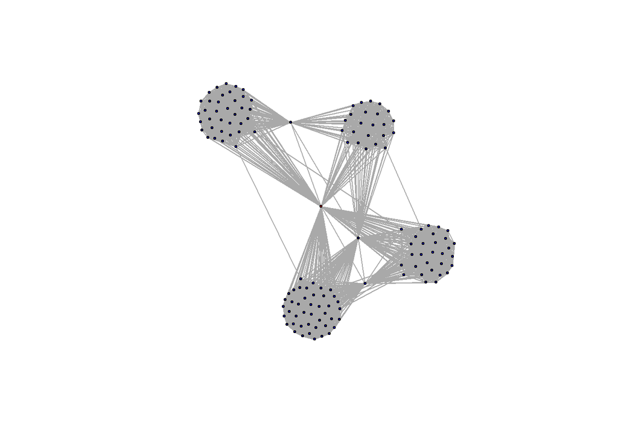

```r
# <answer here>

# Favorite movie----------------------------------------------------------------

chosen.movie <- "Iron Man 3 (2013)"

# Create a subgraph consisting of the chosen movie and its neighbors------------

movie.neighbors <- neighbors(g.movies.subgraph, chosen.movie)

all.vertices.neighbors <- c(V(g.movies.subgraph)[movie.neighbors],
                            V(g.movies.subgraph)[chosen.movie])


# Transforming movie.neighbors in a graph object--------------------------------

g.movie.neighbors <- induced_subgraph(g.movies.subgraph, all.vertices.neighbors)

# Plot the subgraph with the chosen movie in red as focal node and
# neighbors blue----------------------------------------------------------------

plot(g.movie.neighbors, vertex.color = ifelse(V(g.movie.neighbors)$name ==
                                                chosen.movie, "red", "blue"),
     vertex.size = 2, vertex.label = NA)
```

```r
# Calculation of the clustering coefficient-------------------------------------

clustering.coeff <- transitivity(g.movie.neighbors, type = "local",
                                 vids = chosen.movie)

cat("\nThe local clustering coefficient of", chosen.movie,
    "with the neighbors is", clustering.coeff, "\n")
```

```
##
## The local clustering coefficient of Iron Man 3 (2013) with the neighbors is 0.2721946
```

```r
# Extract the list of actors who participated in the chosen movie---------------

# Get the vertex ID of the chosen movie-----------------------------------------

chosen.movie.vertex <- V(g.movies.50)[name == chosen.movie]$name

# Get all the edges that are connected to the chosen movie----------------------

chosen.movie.edges <- E(g.movies.50)[.from(chosen.movie.vertex) |
                                       .to(chosen.movie.vertex)]

# Get the vertex IDs of all the actors connected to the chosen movie------------

chosen.movie.actors <- unique(c(V(g.movies.50)[.from(chosen.movie.edges)]$name,
                                V(g.movies.50)[.to(chosen.movie.edges)]$name))


# Find the set difference between the two lists by using all.actors of task 1---

nonparticipating.actors <- setdiff(all.actors, chosen.movie.actors)

# For each of these actors, count the number of movies they participated in-----

dt.filtered.nonparticipating <- dt.all.movies.selected.actors[
  dt.all.movies.selected.actors$actor %in% nonparticipating.actors$name]

dt.group.actor <- dt.filtered.nonparticipating[, .(freq = .N), by =
                                                 actor]
max.participation.actor <- dt.group.actor[order(-freq)][1]

cat("\nThe actor with the most movie participations among those who did not
    participate in", chosen.movie, "is", max.participation.actor$actor, "with",
    max.participation.actor$freq, "participations.")
```

```
##
## The actor with the most movie participations among those who did not
##     participate in Iron Man 3 (2013) is Robert De Niro (b.1943) with 85 participations.
```

6. Plot the degree distribution of the movies. How do you compare them with the degree distribution of a random graph? What can be plausible explanations for the observed differences? `[2 points]`

Explanations of plausability:

Thus, the preferential attachment random graph best matches the distribution of the original graph.

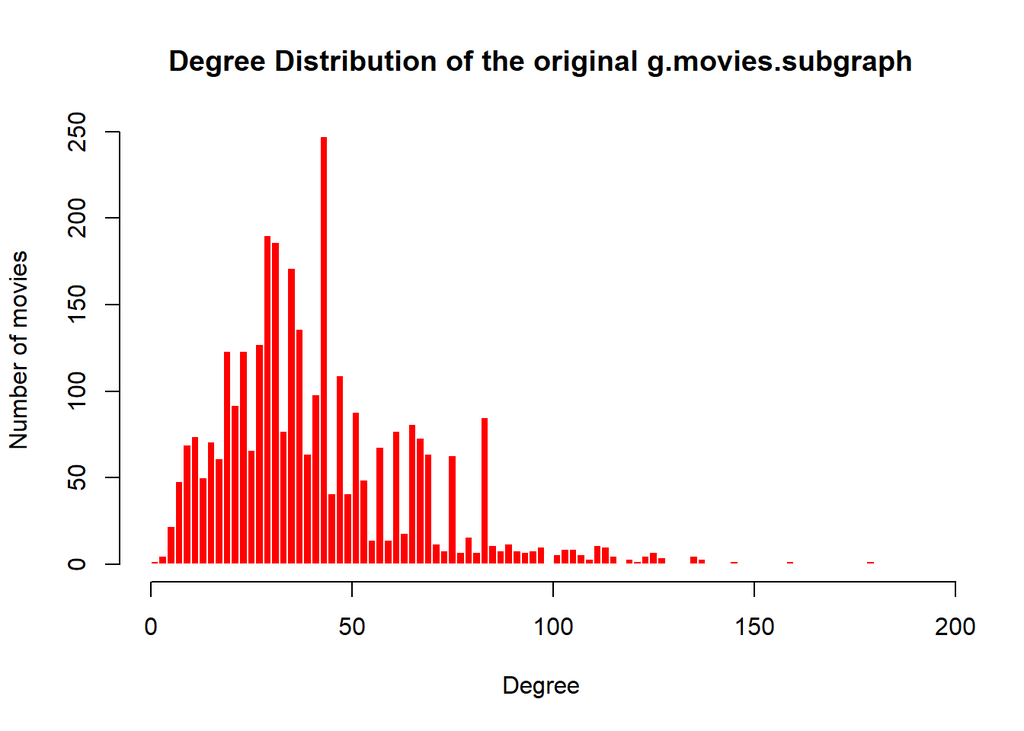

```r
# <answer here>

# Plot the degree distribution for our g.movies.subgraph network and calculate
# the statisitcs to replicate the random graphs below---------------------------

degree.subgraph <- degree(g.movies.subgraph)
hist(degree(g.movies.subgraph),
     main = "Degree Distribution of the original g.movies.subgraph",
     xlab = "Degree", ylab = "Number of movies", col = "red", border = "white",
     breaks = seq(0, max(degree.subgraph) + 10, by = 2))
```

```r
cat("\n Statistical summary of the original graph:\n")
```

```
##
##  Statistical summary of the original graph:
```

```r
mean(degree(g.movies.subgraph))
```

```
## [1] 42.52947
```

```r
transitivity(g.movies.subgraph, type = "average")
```

```
## [1] 0.9233354
```

```r
average.path.length(g.movies.subgraph)
```

```
## [1] 3.203977
```

```r
summary(g.movies.subgraph)
```

```
## IGRAPH 66e21d7 UNW- 3207 68196 --
## + attr: name (v/c), color (v/c), weight (e/n)
```

```r
# Generate a random graph with the number of vertices and edges of the movie
# graph Erdos-Renyi Network-----------------------------------------------------

g.er.random <- sample_gnm(n = vcount(g.movies.subgraph),
                          m = ecount(g.movies.subgraph))

cat("\n Statistical summary of the Erdos-Renyi random graph:\n")
```

```
##
##  Statistical summary of the Erdos-Renyi random graph:
```

```r
mean(degree(g.er.random))
```

```
## [1] 42.52947
```

```r
transitivity(g.er.random, type = "average")
```

```
## [1] 0.01328103
```

```r
average.path.length(g.er.random)
```

```
## [1] 2.54836
```

```r
summary(g.er.random)
```

```
## IGRAPH 8882dbb U--- 3207 68196 -- Erdos-Renyi (gnm) graph
## + attr: name (g/c), type (g/c), loops (g/l), m (g/n)
```

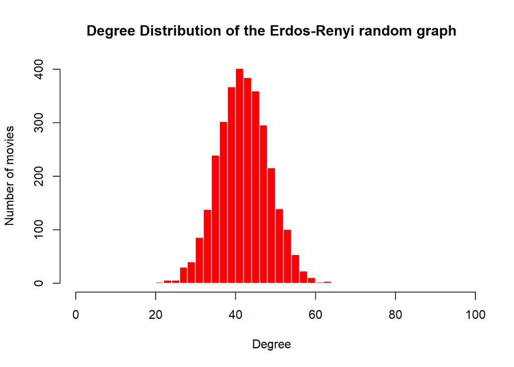

```r
# Plot the degree distribution for the Erdos-Renyi random graph and
# calculate the statisitcs to replicate the random graphs below-----------------

degree.er <- degree(g.er.random)
hist(degree.er,
     main = "Degree Distribution of the Erdos-Renyi random graph",
     xlab = "Degree", ylab = "Number of movies", col = "red", border = "white",
     breaks = seq(0, max(degree.er) + 30, by = 2))
```

```r
# Generate a small world random graph with number of vertices and edges of
# movie graph-------------------------------------------------------------------

g.sw.actors <- sample_smallworld(dim = 1, size = vcount(g.movies.subgraph),
                                 nei = 21, p = 0.02)

cat("\n Statistical summary of the small world random graph:\n")
```

```
##
##  Statistical summary of the small world random graph:
```

```r
mean(degree(g.sw.actors))
```

```
## [1] 42
```

```r
transitivity(g.sw.actors, type = "average")
```

```
## [1] 0.6494712
```

```r
average.path.length(g.sw.actors)
```

```
## [1] 3.260681
```

```r
summary(g.sw.actors)
```

```
## IGRAPH 89522bd U--- 3207 67347 -- Watts-Strogatz random graph
## + attr: name (g/c), dim (g/n), size (g/n), nei (g/n), p (g/n), loops
## | (g/l), multiple (g/l)
```

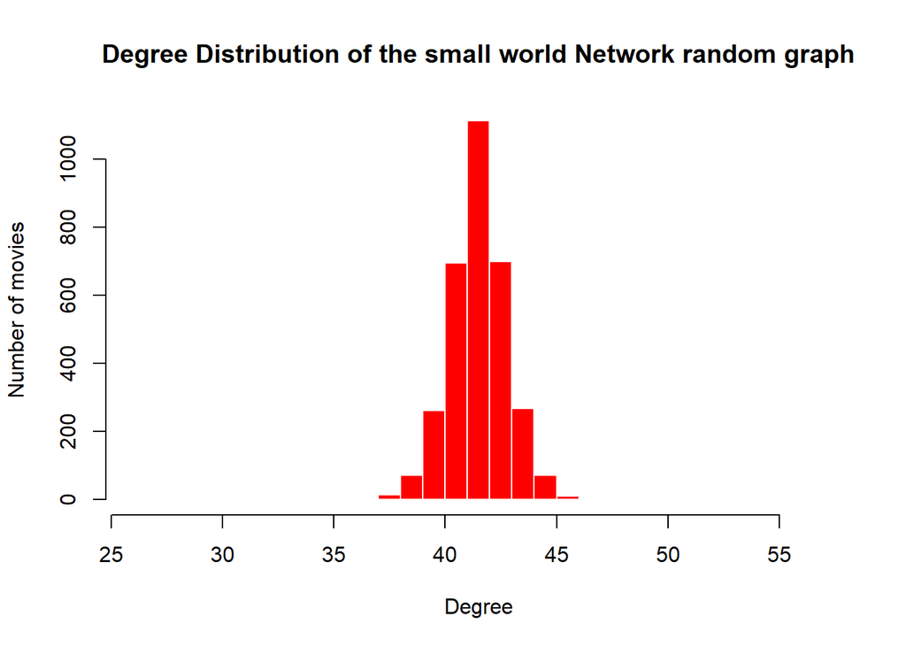

```r
# Plot the degree distribution for the small world Network random graph and
# calculate the statisitcs to replicate the random graphs below-----------------

degree.sm <- degree(g.sw.actors)
hist(degree.sm,
     main = "Degree Distribution of the small world Network random graph",
     xlab = "Degree", ylab = "Number of movies", col = "red", border = "white",
     breaks = seq(min(degree.sm) - 10, max(degree.sm) + 10, by = 1))
```

```r
# Generate a preferential attachment random graph with number of vertices and
# edges of movie graph----------------------------------------------------------

g.pa.actors <- sample_pa(n = vcount(g.movies.subgraph), m = 21,
                         directed = FALSE)

cat("\n Statistical summary of the preferential attachment random graph:\n")
```

```
##
##  Statistical summary of the preferential attachment random graph:
```

```r
mean(degree(g.pa.actors))
```

```
## [1] 41.85594
```

```r
transitivity(g.pa.actors, type = "average")
```

```
## [1] 0.04615795
```

```r
average.path.length(g.pa.actors)
```

```
## [1] 2.468734
```

```r
summary(g.pa.actors)
```

```
## IGRAPH 89e2cfb U--- 3207 67116 -- Barabasi graph
## + attr: name (g/c), power (g/n), m (g/n), zero.appeal (g/n), algorithm
## | (g/c)
```

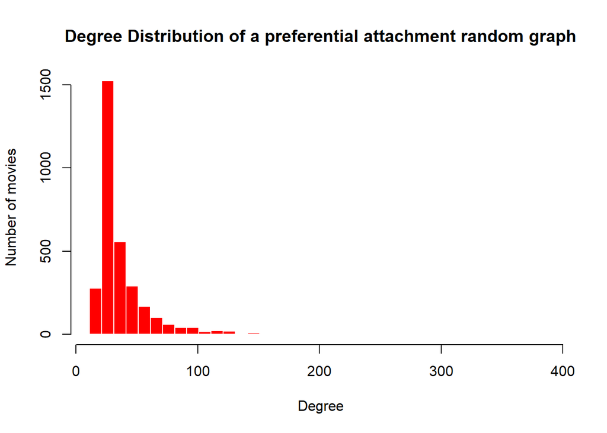

```r
# Plot the degree distribution of the preferential attachment random graph------

degree.pa <- degree(g.pa.actors)
hist(degree.pa,
     main = "Degree Distribution of a preferential attachment random graph",
     xlab = "Degree", ylab = "Number of movies", col = "red", border = "white",
     breaks = seq(min(degree.pa) - 10, max(degree.pa) + 10, by = 10))
```